# Min/Max Parameterization of Spectra

Author

Adam Kemberling

Published

October 9, 2024

```r
# Libraries
library(tidyverse)
library(gmRi)
library(rnaturalearth)
library(scales)
library(sf)
library(gt)
library(patchwork)
library(lmerTest)
library(emmeans)
library(merTools)
library(tidyquant)
library(ggeffects)
library(performance)
library(gtsummary)
library(gt)
library(sizeSpectra)
library(ggdist)
conflicted::conflict_prefer("select", "dplyr")
conflicted::conflict_prefer("filter", "dplyr")
conflicted::conflicts_prefer(lmerTest::lmer)

# Processing functions
source(here::here("Code/R/Processing_Functions.R"))

# ggplot theme
theme_set(
  theme_gmri(
    rect = element_rect(fill = "white", color = NA),
    strip.text.y = element_text(angle  = 0),
    axis.text.x = element_text(size = 8),
    legend.position = "bottom"))



# vectors for factor levels
area_levels <- c("GoM", "GB", "SNE", "MAB")
area_levels_long <- c("Gulf of Maine", "Georges Bank", "Southern New England", "Mid-Atlantic Bight")
# table to join for swapping shorthand for long-hand names
area_df <- data.frame(
  area = c("Scotian Shelf", "Gulf of Maine", "Georges Bank", "Southern New England", "Mid-Atlantic Bight", "All"),
  survey_area = c("SS", "GoM", "GB", "SNE", "MAB", "Northeast Shelf"),
  area_titles = c("Scotian Shelf", "Gulf of Maine", "Georges Bank", "Southern New England", "Mid-Atlantic Bight", "Northeast Shelf"))


# Degree symbol
deg_c <- "\u00b0C"
```

```r
# Load raw
# General tidying only, removal of strata outside our study area, Spring and Fall only
# (removes inshore and rarely/inconsistently sampled strata etc.)
# shrimps removed
trawl_basic <- read_csv(here::here("Data/processed/trawl_clean_all_data.csv"))

# Data used for Wigley estimates
wigley_in <- read_csv(here::here("Data/processed/wigley_species_trawl_data.csv"))

# Finfish before wigley species are pulled out
finfish_in <- read_csv(here::here("Data/processed/finfish_trawl_data.csv"))
```

```r
# Load processing functions
#remotes::install_github("andrew-edwards/sizeSpectra")



# # Run the year, season, area fits for the filtered data
# wigley_bmspectra_16 <- group_binspecies_spectra(
#   ss_input = filter(wigley_in, wmin_g >=16),
#   grouping_vars = c("est_year", "season", "survey_area"),
#   abundance_vals = "numlen_adj",
#   length_vals = "length_cm",
#   use_weight = TRUE,
#   isd_xmin = 16,
#   global_min = TRUE,
#   isd_xmax = NULL,
#   global_max = FALSE,
#   bin_width = 1,
#   vdiff = 2)

# # Save those
# write_csv(
#   wigley_bmspectra_16,
#   here::here("Data/processed/wigley_species_min16_bodymass_spectra.csv"))


# # Read them in, do some plotting
# wigley_bmspectra_16 <- read_csv(
#   here::here("Data/processed/wigley_species_min16_bodymass_spectra.csv")) %>%
#   left_join(area_df) %>%
#   mutate(
#     survey_area = fct_relevel(survey_area, area_levels),
#     size_range = xmax_actual - xmin_actual,
#     area_titles = factor(area_titles, area_levels_long))


#-----------------


# Load processing functions
#remotes::install_github("andrew-edwards/sizeSpectra")



# # Run the year, season, area fits for the filtered data
# wigley_bmspectra_16to50kg <- group_binspecies_spectra(
#   ss_input = filter(
#     wigley_in,
#     wmin_g >=16,
#     wmin_g <= 50000),
#   grouping_vars = c("est_year", "season", "survey_area"),
#   abundance_vals = "numlen_adj",
#   length_vals = "length_cm",
#   use_weight = TRUE,
#   isd_xmin = 16,
#   global_min = TRUE,
#   isd_xmax = NULL,
#   global_max = FALSE,
#   bin_width = 1,
#   vdiff = 2)
#
# # Save those
# write_csv(
#   wigley_bmspectra_16to50kg,
#   here::here("Data/processed/wigley_species_min16_max50kg_bodymass_spectra.csv"))

#
# # Read them in, do some plotting
# wigley_bmspectra_16to50kg <- read_csv(
#   here::here("Data/processed/wigley_species_min16_max50kg_bodymass_spectra.csv")) %>%
#   left_join(area_df) %>%
#   mutate(
#     survey_area = fct_relevel(survey_area, area_levels),
#     size_range = xmax_actual - xmin_actual,
#     area_titles = factor(area_titles, area_levels_long))
```

```r
# 1g min, max comes from group
wigley_bmspectra <- read_csv(
  here::here("Data/processed/wigley_species_bodymass_spectra.csv")) %>%
  mutate(survey_area = factor(survey_area, levels = area_levels))



# 16g min, max comes from group
wigley_bmspectra_16 <- read_csv(
  here::here("Data/processed/wigley_species_min16_bodymass_spectra.csv")) %>%
  left_join(area_df) %>%
  mutate(
    survey_area = fct_relevel(survey_area, area_levels),
    size_range = xmax_actual - xmin_actual,
    area_titles = factor(area_titles, area_levels_long))


# 16g min, max comes from group, sizes over 50kg removed
wigley_bmspectra_16to50kg <- read_csv(
  here::here("Data/processed/wigley_species_min16_max50kg_bodymass_spectra.csv")) %>%
  left_join(area_df) %>%
  mutate(
    survey_area = fct_relevel(survey_area, area_levels),
    size_range = xmax_actual - xmin_actual,
    area_titles = factor(area_titles, area_levels_long))
```

```r
# Function to get the Predictions
# Drop effect fits that are non-significant  ###
get_preds_and_trendsignif <- function(mod_x){
  modx_preds <- as.data.frame(
    # Model predictions
    ggpredict(
      mod_x,
      terms = ~ est_year * survey_area * season) ) %>%
    mutate(
      survey_area = factor(group, levels = area_levels),
      season = factor(facet, levels = c("Spring", "Fall")))

    # Just survey area and year
    modx_emtrend <- emtrends(
      object = mod_x,
      specs =  ~ survey_area*season,
      var = "est_year") %>%
      as_tibble() %>%
      mutate(
        zero = 0,
        non_zero = if_else(between(zero, lower.CL, upper.CL), F, T))

    # Preds with signif
    modx_preds %>% left_join(select(modx_emtrend, survey_area, season, non_zero))

}
```

# Min/Max Parameters Methodology Hangups (New)

I had for a while lacked confidence that the values we have for slopes because I was fixated on a perceived poor fit of actual data to the presumed distributions and the potential mis-application of an assumed pareto distribution.

I have also struggled with what these “faceless” values represent, and whether or not they were some meaningful feature of the community. When feeling unconfident or cynical I worried that we were looking at local changes in slope over some finite range of body-sizes and that this had less meaning than what has been ascribed to it.

I also don’t know whether slopes are comparable across regions. And if we should be fixing the size-range parameters consistently across groups to allow cross comparison, or let them shift to better fit each seasonal subset. Keeping with the original 1g minimum size parameterization. We see these distributions in the wigley species bodymass spectra:

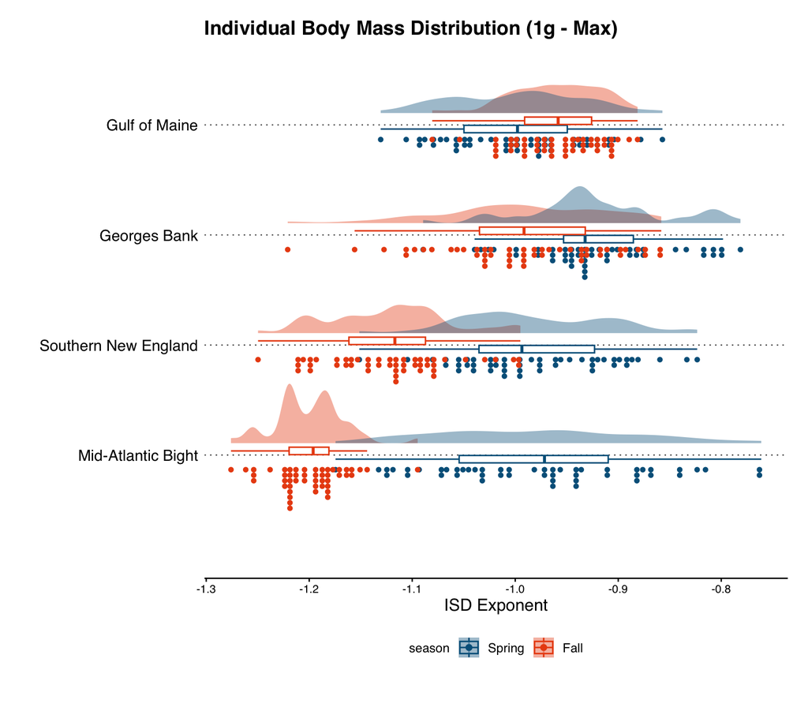

```r
# # Model Dataset for Wigley Species Subset
wigley_bmspectra_model_df <- read_csv(here::here("Data/model_ready/wigley_community_bmspectra_mod.csv"))

# Use one for plots
wigley_bmspectra_model_df <- wigley_bmspectra_model_df %>%
  mutate(survey_area = case_when(
    survey_area == "GoM" ~ "Gulf of Maine",
    survey_area == "GB" ~ "Georges Bank",
    survey_area == "SNE" ~ "Southern New England",
    survey_area == "MAB" ~ "Mid-Atlantic Bight"),
  survey_area = factor(survey_area, levels = area_levels_long),
  season = fct_rev(season))


# Plot the distribution
wigley_b_dist_plot <- wigley_bmspectra_model_df %>%
  ggplot(aes(fct_rev(survey_area), b, color = season, fill = season)) +
  ggdist::stat_halfeye(
     alpha = 0.4,
     adjust = .5,
     width = .6,
    .width = 0,
    justification = -.2,
    point_colour = NA) +
  geom_boxplot(
    fill = "transparent",
    width = .15,
    outlier.shape = NA) +
  ## add dot plots from {ggdist} package
  ggdist::stat_dots(
    ## orientation to the left
    side = "left", size = 1,
    ## move geom to the left
    justification = 1.12,
    ## adjust grouping (binning) of observations
    binwidth = .005) +
  scale_color_gmri() +
  scale_fill_gmri() +
  coord_flip() +
  labs(
    y = "ISD Exponent",
    x = "",
    title = "Individual Body Mass Distribution (1g - Max)")



# Plot on its own
wigley_b_dist_plot
```

### Thoughts on Min/Max Parameters

Our change in growth and fisheries removal hypotheses both relate primarily to abundance of non-age0 fishes.

It might make sense if that is where we are focused to move the minimum size up to something larger and minimize the impact poorly selected size classes and large recruitment events have on the community distribution.

This will accomplish two things: 1) lower any noise in median size or spectra slope that results from large recruit cohorts & 2) help ensure that the size range we’re estimating spectra for are fully selected by the gear.

Currently a 1g minimum size is likely lower than the mesh size selectivity.

This section from Krumsick 2024 describes how this has been handled previously > To account for reduced catchability of small fish,past size- spectrum studies have typically only used size frequency data for size classes larger than the peak size class in observed data (i.e. the descending slope of the observed size-abundance re- lationship) when estimating the slope of sizespectra (e.g.Rice and Gislason 1996, Daan et al. 2005, Krumsick and Fisher 2020).

The following table is a short collection of how authors who cited edwards treated this step:

```r
# Table of papers using mle method and their parameter choices:
lme_params <- tribble(
  ~"Author", ~"Year", ~"Data Used", ~"method", ~"xmin", ~"xmax",
  "Wood", 2024, "Hook and line fisheries dependent reef fishes from fishermen interviews", "log10 bins of 15mm", "141mm", "320mm",

  "Letessier", 2024, "Baited Remote Underwater Video Systems BRUVS", "Two scales: normalized spectra w/ log10 bins for latitudinal brackets, MLE method for individual size distribution for each survey day" , "not reported", "not reported",

  "Rice and Gislason", 1996, "Trawl survey of North Sea Fish + multi-species virtual pop. analysis", "ln
abundance within a size interval (10cm) to ln size intervals", "not stated", "not stated",

  "Daan", 2005, "North Sea fisheries independent trawl surveys", "ln(abundance cpue) within bins ~ 5 & 10cm bins",
  "After inspection of the size range
conforming to a ln-linear slope: ", "size classes at
the lower (poor retention in the gear) and upper (captures
too infrequent for robust estimates) end of the range were
excluded",

  "Krumsick", 2020, "Labrador canada fisheries independent trawl", "...followed recommen-
dations provided by Edwards et al. (2017), although
the prescribed maximum likelihood estimate approach
departed from the empirical data (Fig. S3)... then binned", "64g", "not stated",

"Blanchard", 2009, "North sea predator and detritvore log(abundance/m2) ~ log(bodymass) slopes", "log10 body mass bins", "predators: 256g", "predators: 4kg"

)


lme_params %>% gt()
```

| Author | Year | Data Used | method | xmin | xmax |
| --- | --- | --- | --- | --- | --- |
| Wood | 2024 | Hook and line fisheries dependent reef fishes from fishermen interviews | log10 bins of 15mm | 141mm | 320mm |
| Letessier | 2024 | Baited Remote Underwater Video Systems BRUVS | Two scales: normalized spectra w/ log10 bins for latitudinal brackets, MLE method for individual size distribution for each survey day | not reported | not reported |
| Rice and Gislason | 1996 | Trawl survey of North Sea Fish + multi-species virtual pop. analysis | ln abundance within a size interval (10cm) to ln size intervals | not stated | not stated |
| Daan | 2005 | North Sea fisheries independent trawl surveys | ln(abundance cpue) within bins ~ 5 & 10cm bins | After inspection of the size range conforming to a ln-linear slope: | size classes at the lower (poor retention in the gear) and upper (captures too infrequent for robust estimates) end of the range were excluded |
| Krumsick | 2020 | Labrador canada fisheries independent trawl | ...followed recommen- dations provided by Edwards et al. (2017), although the prescribed maximum likelihood estimate approach departed from the empirical data (Fig. S3)... then binned | 64g | not stated |
| Blanchard | 2009 | North sea predator and detritvore log(abundance/m2) ~ log(bodymass) slopes | log10 body mass bins | predators: 256g | predators: 4kg |

**Log2 Binned Bodymass Distribution**

I’ve highlighted where a minimum body size of 1g sits on this curve to mark where it sits. If the data from the survey were following a pareto distribution over the full range in sizes I would anticipate successive bins to decline, and not increase or remain level for several size ranges to eventually begin declining.

```r
# Broad Distribution
#log2 bins for easy-of-access
#' @title Build Log 2 Bin Structure Dataframe
#'
#' @description Used to build a dataframe containing equally spaced log2 bins for
#' size spectra analysis. Contains details on the left and right limits, midpoint, bin width,
#' and a text label for the bins. log2bin number ascends with increasing size for eeasy plotting.
#'
#' @param log2_min
#' @param log2_max
#' @param log2_increment
#'
#' @return
#' @export
#'
#' @examples
define_log2_bins <- function(log2_min = 0, log2_max = 13, log2_increment = 1){

  # How many bins
  n_bins  <- length(seq(log2_max, log2_min + log2_increment, by = -log2_increment))

  # Build Equally spaced log2 bin df
  log2_bin_structure <- data.frame(
    "log2_bins" = as.character(seq(n_bins, 1, by = -1)),
    "left_lim"  = seq(log2_max - log2_increment, log2_min, by = -log2_increment),
    "right_lim" = seq(log2_max, log2_min + log2_increment, by = -log2_increment)) %>%
    mutate(
      bin_label    = str_c(round(2^left_lim, 3), " - ", round(2^right_lim, 3), "g"),
      bin_width    = 2^right_lim - 2^left_lim,
      bin_midpoint = (2^right_lim + 2^left_lim) / 2) %>%
    arrange(left_lim)

  return(log2_bin_structure)
}






#' @title Assign Manual log2 Bodymass Bins - By weight
#'
#' @description Manually assign log2 bins based on individual length-weight bodymass
#' in increments of 1 on the log2 scale. Returns data with bins assigned based on individual
#' length-weight biomass
#'
#' Uses maximum weight, and its corresponding bin as the limit.
#'
#' @param wmin_grams Catch data prepared for mle calculation, use prep_wmin_wmax
#' @param log2_increment Equally spaced increments to use for log 2 bin sizes. Default = 0.5.
#'
#' @return
#' @export
#'
#' @examples
assign_log2_bins <- function(wmin_grams, log2_increment = 1){


  #### 1. Set up bodymass bins

  # filter missing weights
  size_data <- wmin_grams %>%
    filter(wmin_g > 0,
           is.na(wmin_g) == FALSE,
           wmax_g > 0,
           is.na(wmax_g) == FALSE)

  # Get bodymass on log2() scale
  size_data$log2_weight <- log2(size_data$ind_weight_g)

  # Set up the bins - Pull min and max weights from data available
  #min_bin <- floor(min(size_data$log2_weight))
  min_bin <- 0
  max_bin <- ceiling(max(size_data$log2_weight))


  # Build a bin key, could be used to clean up the incremental assignment or for apply style functions
  log2_bin_structure <- define_log2_bins(
    log2_min = min_bin,
    log2_max = max_bin,
    log2_increment = log2_increment)



  # Loop through bins to assign the bin details to the data
  log2_assigned <- log2_bin_structure %>%
    split(.$log2_bins) %>%
    map_dfr(function(log2_bin){

      # limits and labels
      l_lim   <- log2_bin$left_lim
      r_lim   <- log2_bin$right_lim
      bin_num <- as.character(log2_bin$log2_bin)

      # assign the label to the appropriate bodymasses
      size_data %>% mutate(
        log2_bins = ifelse( between(log2_weight, l_lim, r_lim), bin_num, NA),
        log2_bins = as.character(log2_bins)) %>%
        drop_na(log2_bins)

    })

  # Join in the size bins
  log2_assigned <- left_join(log2_assigned, log2_bin_structure, by = "log2_bins")

  # return the data with the bins assigned
  return(log2_assigned)

}








#' @title Calculate Normalized and De-Normalized Abundances
#'
#' @description For binned size spectra estimation we use the stratified abundance divided by the
#' bin widths (normalized size spectra). Another way to present the data is to de-normalize, which
#' takes those values and multiplies them by the mid-point of the log-scale bins.
#'
#' min/max & bin_increments are used to enforce the presence of a size bin in the event that
#' there is no abundance. This is done for comparing across different groups/areas that should
#' conceivably have the same size range sampled.
#'
#' @param log2_assigned size data containing the bin assignments to use
#' @param min_log2_bin Minimum 2^x value for the size spectra being measured (>=)
#' @param max_log2_bin Maximum 2^x value for the size spectra being measured (<)
#' @param bin_increment The bin-width on log scale that separates each bin
#' @param ... Additional grouping factors with which to aggregate on besides the size bins themselves
#'
#' @return
#' @export
#'
#' @examples
aggregate_log2_bins <- function(
    log2_assigned,
    min_log2_bin = 0,
    max_log2_bin = 13,
    bin_increment = 1,
    ...){

  # Full Possible Bin Structure
  # Fills in any gaps
  log2_bin_structure <- define_log2_bins(
    log2_min       = min_log2_bin,
    log2_max       = max_log2_bin,
    log2_increment = bin_increment)


  # Capture all the group levels with a cheeky expand()
  if(missing(...) == FALSE){
    log2_bin_structure <- log2_bin_structure %>%
      tidyr::expand(left_lim, distinct(log2_assigned, ...)) %>%
      full_join(log2_bin_structure)
  }



  # Get bin breaks
  log2_breaks <- sort(
    unique(c(log2_bin_structure$left_lim, log2_bin_structure$right_lim)))


  # Get Totals for bodymass and abundances
  log2_aggregates <- log2_assigned %>%
    group_by(left_lim, ...) %>%
    summarise(abundance   = sum(numlen_adj, na.rm = T),
              weight_g    = sum(wmin_g, na.rm = T),
              .groups = "drop")


  # Join back in what the limits and labels are
  # The defined bins and their labels enforce the size limits
  log2_prepped <- left_join(
    x = log2_bin_structure,
    y = log2_aggregates)


  #### Fill Gaps with Zero's??
  # This ensures that any size bin that is intended to be in use is actually used
  log2_prepped <- log2_prepped %>%
    mutate(
      abundance = ifelse(is.na(abundance), 1, abundance),
      weight_g = ifelse(is.na(weight_g), 1, weight_g))


  #### normalize abundances using the bin widths
  log2_prepped <- log2_prepped %>%
    mutate(
      normalized_abund = abundance / bin_width,
      normalized_biom = weight_g / bin_width,
      # # Remove Bins Where Normalized Biomass < 0? No!
      # normalized_abund = ifelse(normalized_abund < 2^0, NA, normalized_abund),
      # norm_strat_abund = ifelse(norm_strat_abund < 2^0, NA, norm_strat_abund)
    )

  # Add de-normalized abundances (abundance * bin midpoint)
  log2_prepped <- log2_prepped %>%
    mutate(
      denorm_abund = normalized_abund * bin_midpoint,
      denorm_biom = normalized_biom * bin_midpoint)

  # Return the aggregations
  return(log2_prepped)

}
```

```r
# Assign l2 bins
wigley_log2 <- assign_log2_bins(wigley_in, log2_increment = 1)

# # Aggregate on year, area, season
# wigley_all_aggs <- wigley_log2 %>%
#   aggregate_log2_bins(
#     .,
#     min_log2_bin = 0,
#     max_log2_bin = 10,
#     bin_increment = 1)
#
# # Plot
# ggplot(wigley_all_aggs, aes(2^left_lim, normalized_abund)) +
#   geom_col() +
#   geom_vline(xintercept = 1, linetype = 2, color = "red", linewidth = 1) +
#   geom_label(
#       data = data.frame(val = 1, label = "Current\nMinimum\nSize\nCutoff:\n1g"),
#       aes(x = val, y = I(0.5), label = label),
#       color = "red", label.size = 1,
#       label.padding = unit(0.7, "lines"), label.r = unit(0.5, "lines")) +
#   geom_vline(xintercept = 2^4, linetype = 2, color = "royalblue", linewidth = 1) +
#   geom_label(
#       data = data.frame(val = 2^4, label = "More\nLikely\nFully\nSelected:\n16g"),
#       aes(x = val, y = I(0.5), label = label),
#       color = "royalblue", label.size = 1,
#       label.padding = unit(0.7, "lines"), label.r = unit(0.5, "lines")) +
#   scale_x_continuous(labels = label_log(base = 2), transform = "log2", breaks = 2^c(0:12)) +
#   scale_y_continuous(labels = label_log(base = 2), transform = "log2") +
#   labs(
#     x = "Individual Body Weight (g)",
#     y = "Normalized Abundance\n(total abundance / bin width)",
#   title = "All-year, all-season size spectrum for Wigley Species Subset")
```

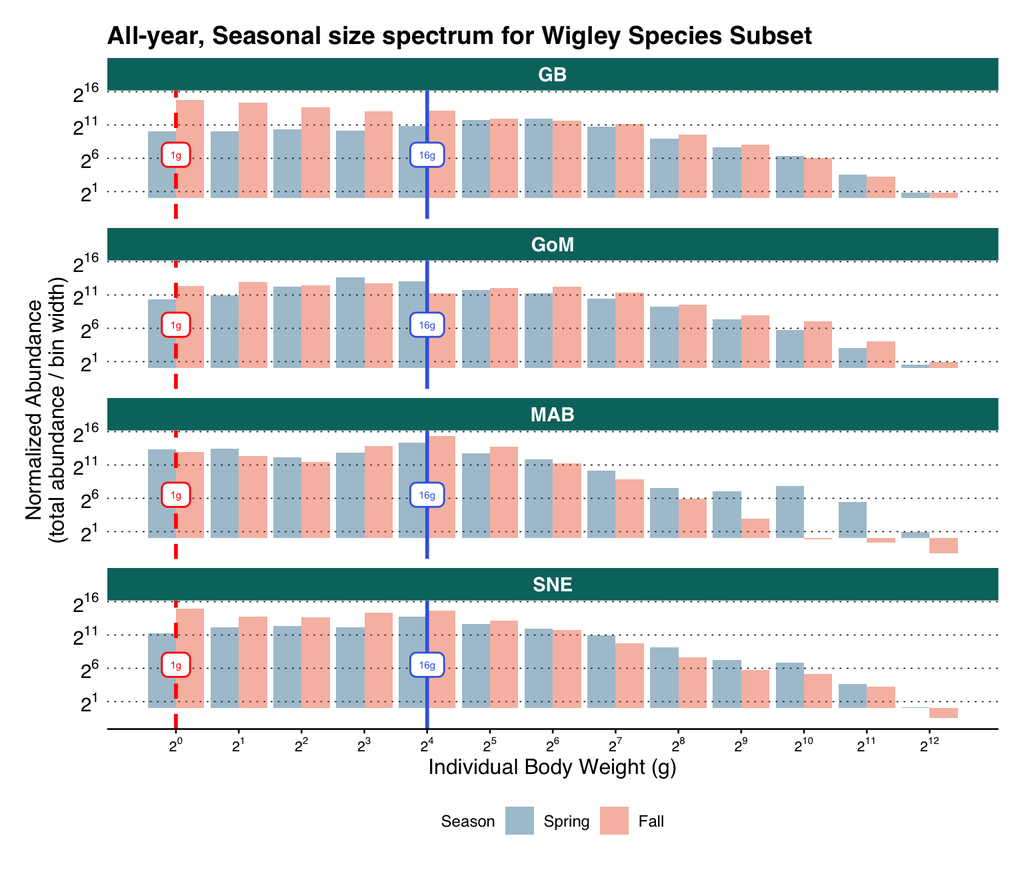

```r
# Aggregate on year, area, season
wigley_season_aggs <- wigley_log2 %>%
  mutate(group_var = str_c(survey_area, "_", season)) %>%
  split(.$group_var) %>%
  map_dfr(
    ~aggregate_log2_bins(
      .x,
      min_l10_bin = 0,
      max_l10_bin = 10,
      bin_increment = 1),
    .id = "group_var") %>%
  separate(col = group_var, into = c("survey_area", "season")) %>%
  mutate(season = fct_rev(season))


# Plot
ggplot(wigley_season_aggs, aes(2^left_lim, normalized_abund)) +
  geom_col(aes(fill = season),  position = "dodge", alpha  = 0.4) +
  geom_vline(xintercept = 1, linetype = 2, color = "red", linewidth = 1) +
  geom_label(
      data = data.frame(val = 1, label = "1g"),
      aes(x = val, y = I(0.5), label = label),
      color = "red", label.size = 0.5, size = 2,
      label.padding = unit(0.7, "lines"), label.r = unit(0.5, "lines")) +
  geom_vline(xintercept = 2^4, linetype = 1, color = "royalblue", linewidth = 1) +
  geom_label(
      data = data.frame(val = 2^4, label = "16g"),
      aes(x = val, y = I(0.5), label = label),
      color = "royalblue", label.size = 0.5, size = 2,
      label.padding = unit(0.7, "lines"), label.r = unit(0.5, "lines")) +
  scale_fill_gmri() +
  scale_x_continuous(labels = label_log(base = 2), transform = "log2", breaks = 2^c(0:12)) +
  scale_y_continuous(labels = label_log(base = 2), transform = "log2") +
  facet_wrap(~survey_area, ncol = 1, scales = "fixed") +
  labs(
    x = "Individual Body Weight (g)",
    y = "Normalized Abundance\n(total abundance / bin width)",
    fill = "Season",
    title = "All-year, Seasonal size spectrum for Wigley Species Subset")
```

We could probably be more scientific than visually picking the inflection point and look at the mesh size used (codend liner 1 inch stretched diamond mesh), but I think precision there is less important that being closer than we are now. In all regions it seems like the typical linear slope begins at a larger size than 1g.

**Log2 Binned Length Distributions**

The length distributions look even more flat than the biomass distributions, basically ending at the 128-256cm bin. If we go with the Full finfish community we may want to look more closely at the max-size parameter.

Here is what the length distirbution looks like for the broader finfish community:

```r
# Broad Distribution
#log2 bins for easy-of-access
#' @title Build Log 2 Bin Structure Dataframe
#'
#' @description Used to build a dataframe containing equally spaced log2 bins for
#' size spectra analysis. Contains details on the left and right limits, midpoint, bin width,
#' and a text label for the bins. log2bin number ascends with increasing size for eeasy plotting.
#'
#' @param log2_min
#' @param log2_max
#' @param log2_increment
#'
#' @return
#' @export
#'
#' @examples
define_log2_bins <- function(log2_min = 0, log2_max = 13, log2_increment = 1){

  # How many bins
  n_bins  <- length(seq(log2_max, log2_min + log2_increment, by = -log2_increment))

  # Build Equally spaced log2 bin df
  log2_bin_structure <- data.frame(
    "log2_bins" = as.character(seq(n_bins, 1, by = -1)),
    "left_lim"  = seq(log2_max - log2_increment, log2_min, by = -log2_increment),
    "right_lim" = seq(log2_max, log2_min + log2_increment, by = -log2_increment)) %>%
    mutate(
      bin_label    = str_c(round(2^left_lim, 3), " - ", round(2^right_lim, 3), "g"),
      bin_width    = 2^right_lim - 2^left_lim,
      bin_midpoint = (2^right_lim + 2^left_lim) / 2) %>%
    arrange(left_lim)

  return(log2_bin_structure)
}





#' @title Assign Manual log2 Bodymass Bins - By weight
#'
#' @description Manually assign log2 bins based on individual length-weight bodymass
#' in increments of 1 on the log2 scale. Returns data with bins assigned based on individual
#' length-weight biomass
#'
#' Uses maximum weight, and its corresponding bin as the limit.
#'
#' @param wmin_grams Catch data prepared for mle calculation, use prep_wmin_wmax
#' @param log2_increment Equally spaced increments to use for log 2 bin sizes. Default = 0.5.
#'
#' @return
#' @export
#'
#' @examples
assign_log2_len_bins <- function(
    size_increment_df,
    metric_col = "length_cm",
    log2_increment = 1){


  #### 1. Set up bodymass bins

  # filter missing weights
  size_data <- size_increment_df %>%
    mutate(
      min_size = {{metric_col}},
      max_size = {{metric_col}}) %>%
    filter(
      min_size > 0,
      is.na(min_size) == FALSE,
      max_size > 0,
      is.na(max_size) == FALSE)

  # Get bodymass on log2() scale
  size_data$log2_size <- log2(size_data[[metric_col]])

  # Set up the bins - Pull min and max weights from data available
  #min_bin <- floor(min(size_data$log2_weight))
  min_bin <- 0
  max_bin <- ceiling(max(size_data$log2_size))


  # Build a bin key, could be used to clean up the incremental assignment or for apply style functions
  log2_bin_structure <- define_log2_bins(
    log2_min = min_bin,
    log2_max = max_bin,
    log2_increment = log2_increment)



  # Loop through bins to assign the bin details to the data
  log2_assigned <- log2_bin_structure %>%
    split(.$log2_bins) %>%
    map_dfr(function(log2_bin){

      # limits and labels
      l_lim   <- log2_bin$left_lim
      r_lim   <- log2_bin$right_lim
      bin_num <- as.character(log2_bin$log2_bin)

      # assign the label to the appropriate bodymasses
      size_data %>% mutate(
        log2_bins = ifelse(between(log2_size, l_lim, r_lim), bin_num, NA),
        log2_bins = as.character(log2_bins)) %>%
        drop_na(log2_bins)

    })

  # Join in the size bins
  log2_assigned <- left_join(log2_assigned, log2_bin_structure, by = "log2_bins")

  # return the data with the bins assigned
  return(log2_assigned)

}



# # Test it
# finfish_log2 <- assign_log2_len_bins(size_increment_df = finfish_in, metric_col = "length_cm")







#' @title Calculate Normalized and De-Normalized Abundances
#'
#' @description For binned size spectra estimation we use the stratified abundance divided by the
#' bin widths (normalized size spectra). Another way to present the data is to de-normalize, which
#' takes those values and multiplies them by the mid-point of the log-scale bins.
#'
#' min/max & bin_increments are used to enforce the presence of a size bin in the event that
#' there is no abundance. This is done for comparing across different groups/areas that should
#' conceivably have the same size range sampled.
#'
#' @param log2_assigned size data containing the bin assignments to use
#' @param min_log2_bin Minimum 2^x value for the size spectra being measured (>=)
#' @param max_log2_bin Maximum 2^x value for the size spectra being measured (<)
#' @param bin_increment The bin-width on log scale that separates each bin
#' @param ... Additional grouping factors with which to aggregate on besides the size bins themselves
#'
#' @return
#' @export
#'
#' @examples
aggregate_log2_len_bins <- function(
    log2_assigned,
    min_log2_bin = 0,
    max_log2_bin = 13,
    bin_increment = 1,
    ...){

  # Full Possible Bin Structure
  # Fills in any gaps
  log2_bin_structure <- define_log2_bins(
    log2_min       = min_log2_bin,
    log2_max       = max_log2_bin,
    log2_increment = bin_increment)


  # Capture all the group levels with a cheeky expand()
  if(missing(...) == FALSE){
    log2_bin_structure <- log2_bin_structure %>%
      tidyr::expand(left_lim, distinct(log2_assigned, ...)) %>%
      full_join(log2_bin_structure)
  }



  # Get bin breaks
  log2_breaks <- sort(
    unique(c(log2_bin_structure$left_lim, log2_bin_structure$right_lim)))


  # Get Totals for bodymass and abundances
  log2_aggregates <- log2_assigned %>%
    group_by(left_lim, ...) %>%
    summarise(
      abundance   = sum(numlen_adj, na.rm = T),
      .groups = "drop")


  # Join back in what the limits and labels are
  # The defined bins and their labels enforce the size limits
  log2_prepped <- left_join(
    x = log2_bin_structure,
    y = log2_aggregates)


  #### Fill Gaps with Zero's??
  # This ensures that any size bin that is intended to be in use is actually used
  log2_prepped <- log2_prepped %>%
    mutate(
      abundance = ifelse(is.na(abundance), 1, abundance))


  #### normalize abundances using the bin widths
  log2_prepped <- log2_prepped %>%
    mutate(
      normalized_abund = abundance / bin_width)

  # Add de-normalized abundances (abundance * bin midpoint)
  log2_prepped <- log2_prepped %>%
    mutate(denorm_abund = normalized_abund * bin_midpoint)

  # Return the aggregations
  return(log2_prepped)

}
```

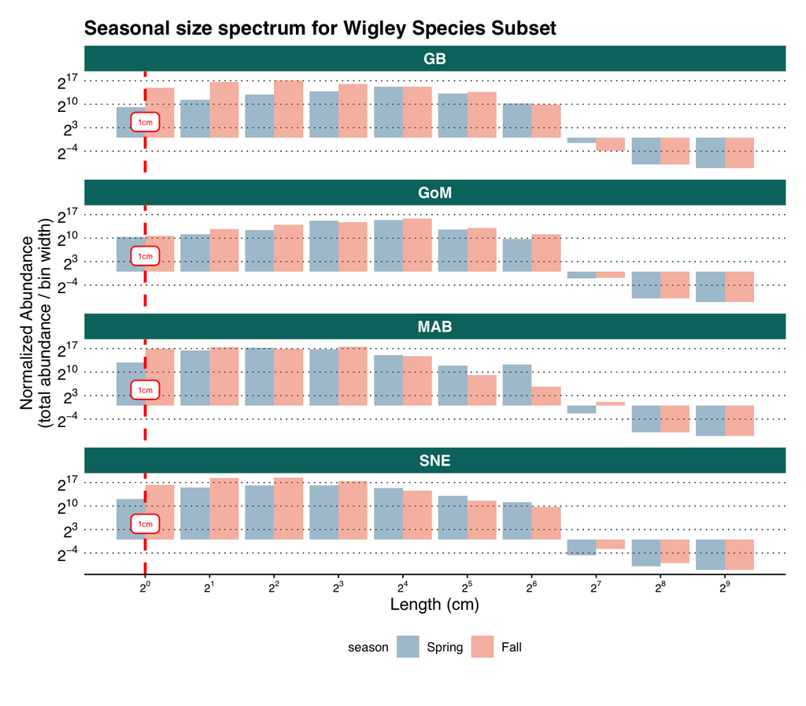

```r
# Gotta change the columns that the bins are built on
# Assign l2 bins
finfish_log2_lens <- assign_log2_len_bins(
  size_increment_df = finfish_in,
  metric_col = "length_cm",
  log2_increment = 1)

# Aggregate on year, area, season
finfish_season_len_aggs <- finfish_log2_lens %>%
  mutate(group_var = str_c(survey_area, "_", season)) %>%
  split(.$group_var) %>%
  map_dfr(
    ~aggregate_log2_len_bins(
      .x,
      min_log2_bin = 0,
      max_log2_bin = 10,
      bin_increment = 1),
    .id = "group_var") %>%
  separate(col = group_var, into = c("survey_area", "season")) %>%
  mutate(season = fct_rev(season))


# Plot
ggplot(finfish_season_len_aggs, aes(2^left_lim, normalized_abund)) +
  geom_col(aes(fill = season),  position = "dodge", alpha  = 0.4) +
  geom_vline(xintercept = 1, linetype = 2, color = "red", linewidth = 1) +
  geom_label(
      data = data.frame(val = 1, label = "1cm"),
      aes(x = val, y = I(0.5), label = label),
      color = "red", label.size = 0.5, size = 2,
      label.padding = unit(0.7, "lines"), label.r = unit(0.5, "lines")) +
  scale_fill_gmri() +
  scale_x_continuous(labels = label_log(base = 2), transform = "log2", breaks = 2^c(0:12)) +
  scale_y_continuous(labels = label_log(base = 2), transform = "log2") +
  facet_wrap(~survey_area, ncol = 1, scales = "fixed") +
  labs(
    x = "Length (cm)",
    y = "Normalized Abundance\n(total abundance / bin width)",
    color = "Season",
    title = "Seasonal size spectrum for Wigley Species Subset")
```

## Is it even Pareto?

I still have some concerns about this, but I think I’m mostly over it and we don’t have time or a plan to check and address them.

Other authors have raised this issue, but there is no clear advisement on how to assess/approach situations where the pareto or power law distributions are not appropriate. In Krumsick et al. 2020 they determined visually that their data from the trawl data did not follow the distribution assumed by the MLE methodology and instead turned to normalized spectra using binned methods.

# What if we shifted minimum size to 16g?

I’m just going to go ahead and shift the minimum size cutoff to 16g and see what the consequences are:

After doing some attempts to plot the impacts of moving it around, I am less convinced that its necessary, though it does result in steeper slopes over these sizes.

**Trend Consequences**

With respect to trends, by shifting to 16g we lose the fall steepening ocurring in the Gulf of Maine, otherwise the direction of trends remain the same.

```r
# Model signigicant trends


# Model trends for 1g min size
bmspectra_1g_mod_wig <- lmer(
  formula = b ~ est_year * survey_area * season + (1|est_year),
  data = wigley_bmspectra)

# Get significant trends
trend_predictions_1g <- get_preds_and_trendsignif(bmspectra_1g_mod_wig) %>%
  mutate(model_id = "bodymass_spectra-Wigley Subset, 1g min") %>%
  separate(model_id, into = c("metric", "community"), sep = "-") %>%
  mutate(metric = fct_rev(metric), survey_area = fct_relevel(survey_area, area_levels))





# Model trends for 16g min size
bmspectra_16g_mod_wig <- lmer(
  formula = b ~ est_year * survey_area * season + (1|est_year),
  data = wigley_bmspectra_16)


# Get the predictions and flag whether they are significant
trend_predictions_16g <- get_preds_and_trendsignif(bmspectra_16g_mod_wig) %>%
  mutate(model_id = "bodymass_spectra-Wigley Subset, 16g min") %>%
  separate(model_id, into = c("metric", "community"), sep = "-") %>%
  mutate(metric = fct_rev(metric), survey_area = fct_relevel(survey_area, area_levels))
```

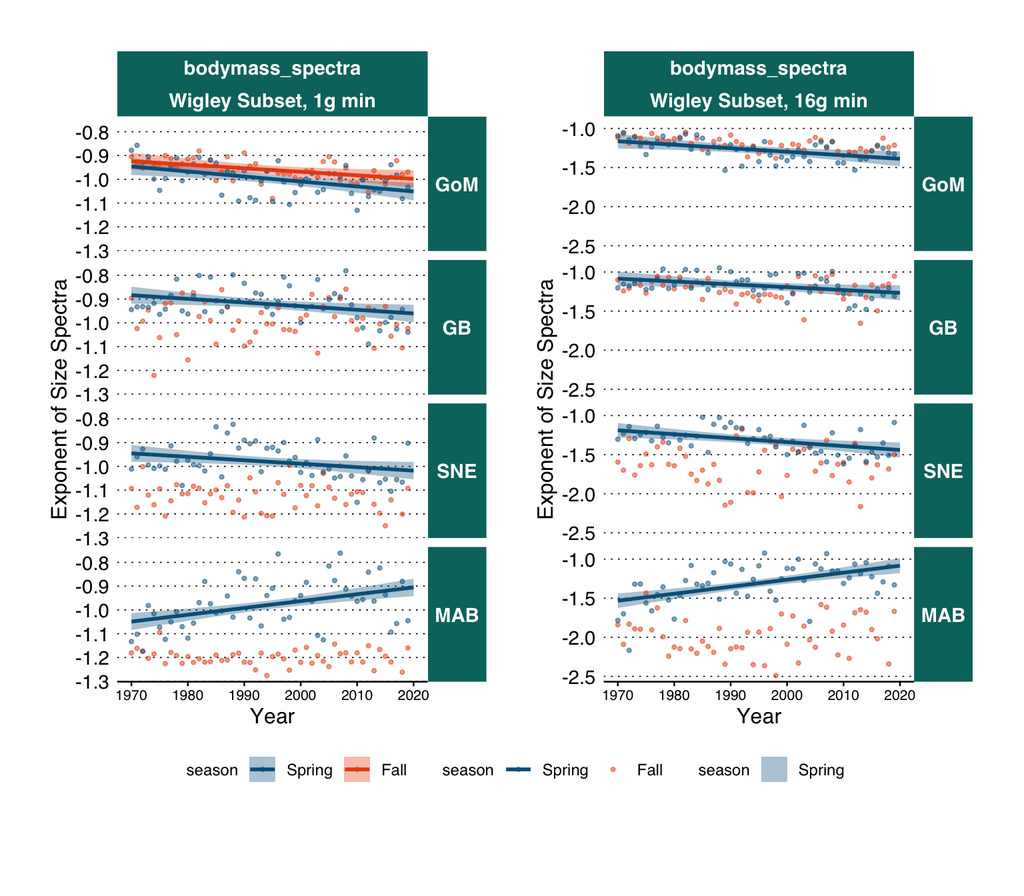

```r
# Plot significant trends over observed data
# Compare to previous plot for 1g min size
wigley_trends_1g <- ggplot() +
   geom_ribbon(
    data = filter(trend_predictions_1g, non_zero == TRUE),
    aes(x, ymin = conf.low, ymax = conf.high, fill = season),
    linewidth = 1, alpha = 0.35) +
  geom_point(
    data = wigley_bmspectra,
    aes(est_year, b, color = season),
    size = 0.8, alpha = 0.5) +
  geom_line(
    data = filter(trend_predictions_1g, non_zero == TRUE),
    aes(x, predicted, color = season),
    linewidth = 1, alpha = 1) +
  scale_fill_gmri() +
  scale_color_gmri() +
  scale_y_continuous() +
  facet_grid(survey_area ~ metric*community) +
  labs(
    x = "Year",
    y = "Exponent of Size Spectra")



# Make the plot for 16g min size
spectra_trends_16g <- ggplot() +
   geom_ribbon(
    data = filter(trend_predictions_16g, non_zero == TRUE),
    aes(x, ymin = conf.low, ymax = conf.high, fill = season),
    linewidth = 1, alpha = 0.35) +
  geom_point(
    data = wigley_bmspectra_16,
    aes(est_year, b, color = season),
    size = 0.8, alpha = 0.5) +
  geom_line(
    data = filter(trend_predictions_16g, non_zero == TRUE),
    aes(x, predicted, color = season),
    linewidth = 1, alpha = 1) +
  scale_fill_gmri() +
  scale_color_gmri() +
  scale_y_continuous() +
  facet_grid(survey_area ~ metric*community) +
  labs(
    x = "Year",
    y = "Exponent of Size Spectra")






(wigley_trends_1g | spectra_trends_16g) + plot_layout(guides = "collect") & theme(legend.position = "bottom")
```

**Across Group Difference Consequences**

One of the original hypotheses was that under warming the size distribution in the Northern, colder regions would begin to resemble the size distributions of more southern, warmer regions.

Whether or not we shift the size range, the distributions seem similarly distinct.

To be directly comparable I had thought it might be important to restrict the range of sizes that we consider when estimating the exponent of the individual size distribution.

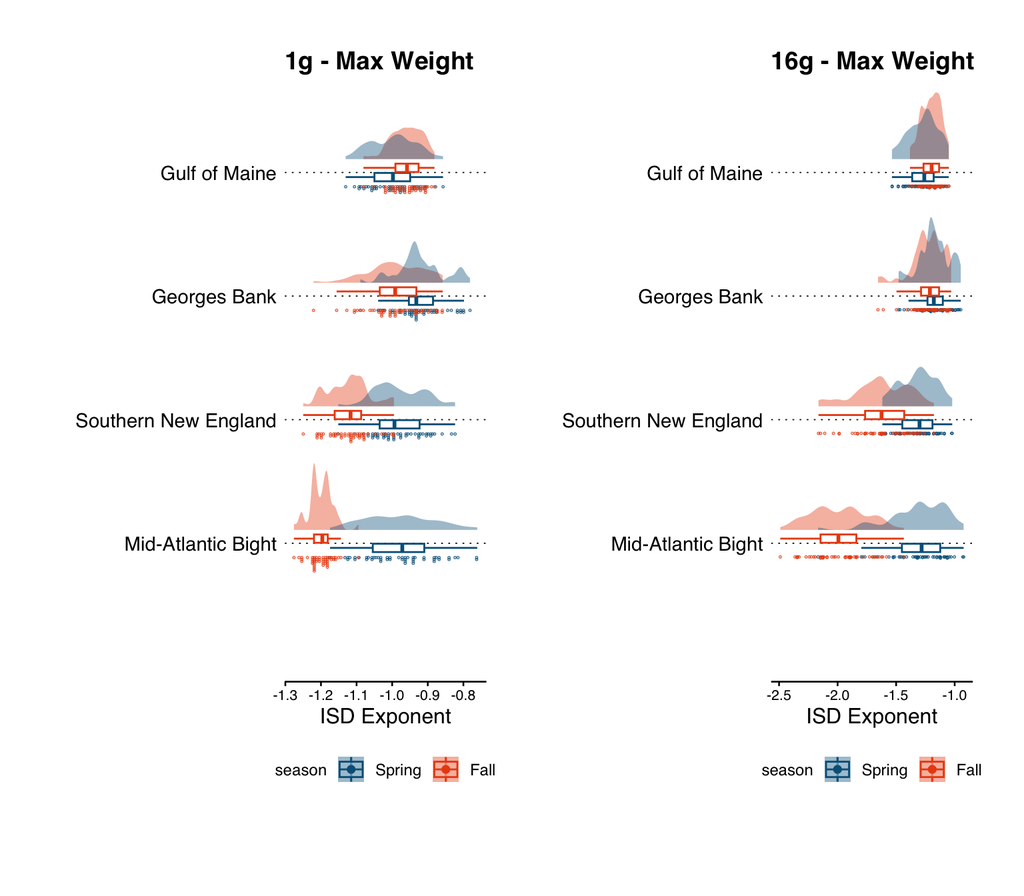

```r
# Plot what the 1g min size distributions look like
dist_plot_1g <- wigley_bmspectra_model_df %>%
  ggplot(aes(fct_rev(survey_area), b, color = season, fill = season)) +
  ggdist::stat_halfeye(
     alpha = 0.4,
     adjust = .5,
     width = .6,
    .width = 0,
    justification = -.2,
    point_colour = NA
  ) +
  geom_boxplot(
    fill = "transparent",
    width = .15,
    outlier.shape = NA) +
  ## add dot plots from {ggdist} package
  ggdist::stat_dots(
    ## orientation to the left
    side = "left", size = 1,
    ## move geom to the left
    justification = 1.12,
    ## adjust grouping (binning) of observations
    binwidth = .005) +
  scale_color_gmri() +
  scale_fill_gmri() +
  coord_flip() +
  labs(
    y = "ISD Exponent",
    x = "",
    title = "1g - Max Weight")


# Plot the 16g min size
dist_plot_16g <- wigley_bmspectra_16 %>%
# dist_plot_16g <- wigley_bmspectra_16to50kg %>%
  mutate(season = fct_rev(season)) %>%
ggplot(aes(fct_rev(area_titles), b, color = season, fill = season)) +
   ggdist::stat_halfeye(
     alpha = 0.4,
     adjust = .5,
     width = .6,
    .width = 0,
    justification = -.2,
    point_colour = NA) +
  geom_boxplot(
    fill = "transparent",
    width = .15,
    outlier.shape = NA) +
  ## add dot plots from {ggdist} package
  ggdist::stat_dots(
    ## orientation to the left
    side = "left", size = 1,
    ## move geom to the left
    justification = 1.12,
    ## adjust grouping (binning) of observations
    binwidth = .005) +
  scale_color_gmri() +
  scale_fill_gmri() +
  coord_flip() +
  labs(
    y = "ISD Exponent",
    x = "",
    title = "16g - Max Weight")



dist_plot_1g | dist_plot_16g
```

**Size Ranges Covered by ISD Fitting**

Before I plotted the distributions of exponent values before/after shifting minimum size, I was concerned about the absolute values shifting in a meaningful way.

I’m less concerned now, but the range of sizes spanneed in the MAB seem much larger than the other regions.

The below plot shows the variance in min-max size ranges for the size distribution fits. There is a much larger range in the Mid-Atlantic.

We may want to drop some outliers there to be more consistent in the range of sizes we are comparing.

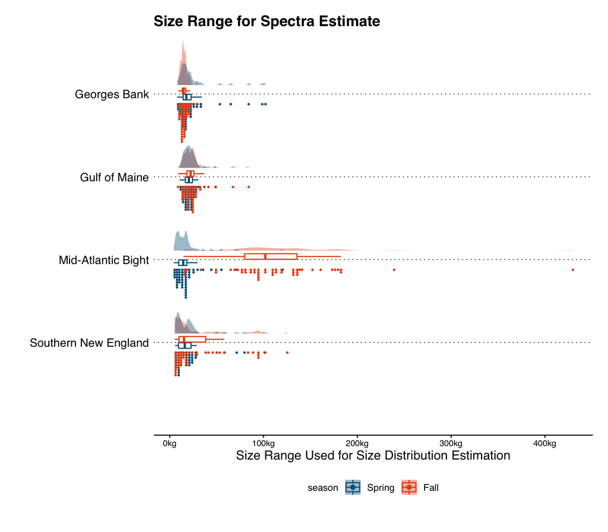

```r
# Size ranges as distribution
p1 <- wigley_bmspectra_model_df %>%
  left_join(area_df) %>%
  mutate(size_range = xmax_actual - xmin_actual,
         size_range_kg = size_range/1000) %>%
  ggplot(aes(fct_rev(area_titles), size_range_kg,  color = season, fill = season)) +
  ggdist::stat_halfeye(
     alpha = 0.4,
     adjust = .5,
     width = .6,
    .width = 0,
    justification = -.2,
    point_colour = NA) +
  geom_boxplot(
    fill = "transparent",
    width = .15,
    outlier.shape = NA) +
  ## add dot plots from {ggdist} package
  ggdist::stat_dots(
    ## orientation to the left
    side = "left", size = 1,
    ## move geom to the left
    justification = 1.12,
    ## adjust grouping (binning) of observations
    binwidth = 2.5) +
  scale_color_gmri() +
  scale_fill_gmri() +
  coord_flip() +
  scale_y_continuous(labels = label_number(suffix = "kg")) +
  labs(
    title = "Size Range for Spectra Estimate",
    x = "",
    y = "Size Range Used for Size Distribution Estimation")


p1
```

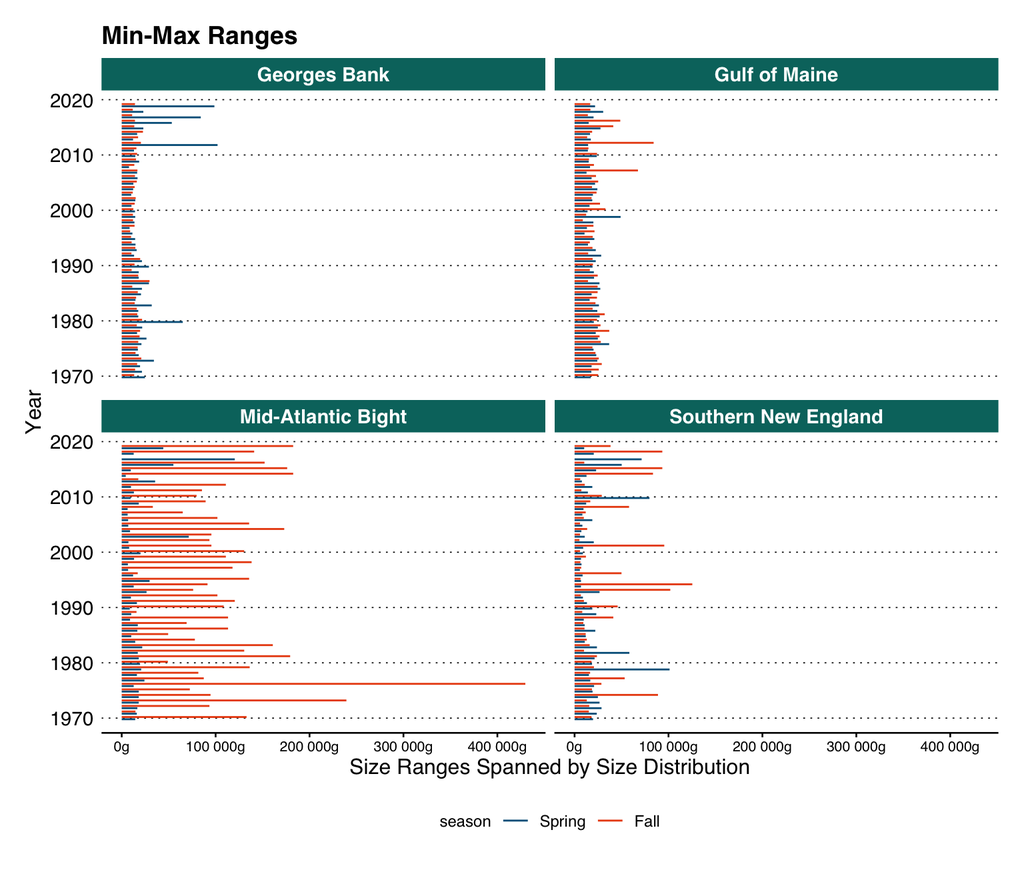

```r
# Plot the ranges as bars
p2 <- wigley_bmspectra_model_df %>%
  left_join(area_df) %>%
  mutate(est_year = if_else(season == "Spring", est_year-0.2, est_year+0.2)) %>%
  ggplot(aes(x = xmin_fit, xend = xmax_fit, y = est_year,  yend = est_year, color = season)) +
  geom_segment() +
  scale_color_gmri() +
  scale_fill_gmri() +
  facet_wrap(~area_titles, ncol = 2) +
  scale_x_continuous(labels = label_number(suffix = "g")) +
  labs(
    title = "Min-Max Ranges",
    x = "Size Ranges Spanned by Size Distribution",
    y = "Year")

 p2
```

### Visualizing Size Distribution “Fits”

I found the bug that made the fits look strange, I was fitting length spectra and then plotting mass points.

The following plots will go over the consequences of changing min/max limits when fitting the ISD for Mid-Atlantic Bight in Fall of 1976, a year with an exceptionally hefty individual that drags the size range to an extreme.

```r
# Prepare inputs directly:
yr_op <- c(1976)
reg   <- "MAB"
seas  <- "Fall"


# Data for the spectra
actual_vals_1g <- wigley_in %>%
  filter(
    est_year %in% yr_op,
    survey_area == reg,
    season == seas,
    wmin_g >= 1)

# Filtered to above 16g
actual_vals_16g <- wigley_in %>%
  filter(
    est_year %in% yr_op,
    survey_area == reg,
    season == seas,
    wmin_g >= 16)

# Filtered to above 16g, below 50kg
actual_vals_16to50kg <- wigley_in %>%
  filter(
    est_year %in% yr_op,
    survey_area == reg,
    season == seas,
    wmin_g >= 16,
    wmax_g <= 50000)
```

## Sensitivity to minimum/maximum size

Even when shifting the minimum size, its not clear that the size distribution now follows the pareto distribution more closely.

Its easier to quickly look at the binned versions, but then we’re hopping across methods again.

I tracked down the plotting bug, but its still likely not something we can allocate resources to worrying about.

```r
# Load processing functions
source(here::here("Code/R/Processing_Functions.R"))


# group_binspecies_spectra uses sizeSpectra::negLL.PLB.bins.species


# Get the slope over those years
mle_results_1g <- group_binspecies_spectra(
    ss_input = actual_vals_1g,
    grouping_vars = c("est_year", "season", "survey_area"),
    abundance_vals = "numlen_adj",
    length_vals = "length_cm",
    use_weight = TRUE,
    isd_xmin = 1,
    global_min = TRUE,
    isd_xmax = NULL,
    global_max = FALSE,
    bin_width = 1,
    vdiff = 2)



# and again for 16g
mle_results_16g <- group_binspecies_spectra(
    ss_input = actual_vals_16g,
    grouping_vars = c("est_year", "season", "survey_area"),
    abundance_vals = "numlen_adj",
    length_vals = "length_cm",
    use_weight = TRUE,
    isd_xmin = 16,
    global_min = TRUE,
    isd_xmax = NULL,
    global_max = FALSE,
    bin_width = 1,
    vdiff = 2)



# and again for 16g to 50kg
mle_results_16to50kg <- group_binspecies_spectra(
    ss_input = actual_vals_16to50kg,
    grouping_vars = c("est_year", "season", "survey_area"),
    abundance_vals = "numlen_adj",
    length_vals = "length_cm",
    use_weight = TRUE,
    isd_xmin = 16,
    global_min = TRUE,
    isd_xmax = NULL,
    global_max = FALSE,
    bin_width = 1,
    vdiff = 2)
```

```r
#' @title Individual Size Distribution Plot Prep
#'
#' @description Prepares wmin_grams data to be plotted with the MLE
#' size spectrum slope fit.
#'
#' @param biomass_data Data prepped for mle estimation, use prep_wmin_wmax
#' @param min_weight_g Minimum weight cutoff to use to match bounded pareto minimum
#'
#' @return
#' @export
#'
#' @examples
isd_plot_prep <- function(
    biomass_data = databin_split,
    min_weight_g = 1){

  # Arrange by lower weight
  biomass_data <- dplyr::arrange(biomass_data, desc(wmin_g)) %>%
    select(wmin_g, wmax_g, numlen_adj)

  # truncate the data to in match the spectra we fit's xmin/xmax
  biomass_data <- biomass_data %>%
    filter(wmin_g >= min_weight_g,
           wmin_g != 0,
           is.na(wmin_g) == FALSE,
           wmax_g != 0,
           is.na(wmax_g) == FALSE)

  # Get the total number of fish for the group
  total_abundance <- sum(biomass_data$numlen_adj)

  # Have to do not with dplyr:
  wmin.vec <- biomass_data$wmin_g      # Vector of lower weight bin limits
  wmax.vec <- biomass_data$wmax_g      # Vector of upper weight bin limits
  num.vec  <- biomass_data$numlen_adj  # Vector of corresponding counts for those bins

  # doing it with purr and pmap
  biomass_bins <- select(biomass_data, wmin_g, wmax_g) %>%
    distinct(wmin_g, wmax_g)

  # Go row-by-row and get the cumulative total greater than each
  # minimum weight bin discrete size bin
  out_data <- pmap_dfr(biomass_bins, function(wmin_g, wmax_g){

    # 1. Count times wmin.vec >= individual wmin_g, multiply by number of fish for year
    # cumulative totals of sizes larger than the left lim
    countGTEwmin <- sum( (wmin.vec >= wmin_g) * num.vec)

    # 2. Count times wmin.vec >= individual wmax_g, multiply by number of fish for year
    # cumulative totals of sizes larger than the right lim
    lowCount <- sum( (wmin.vec >= wmax_g) * num.vec)

    # 3. Count times wmax.vec > individual wmin_g, multiply by number of fish for year
    highCount <- sum( (wmax.vec >  wmin_g) * num.vec)

    # 4. build table
    out_table <- data.frame(
      "wmin_g"       = wmin_g,
      "wmax_g"       = wmax_g,
      "countGTEwmin" = countGTEwmin,
      "lowCount"     = lowCount,
      "highCount"    = highCount
    )
  })



  # return the purr version
  return(out_data)




}
```

**1g Min Cutoff**

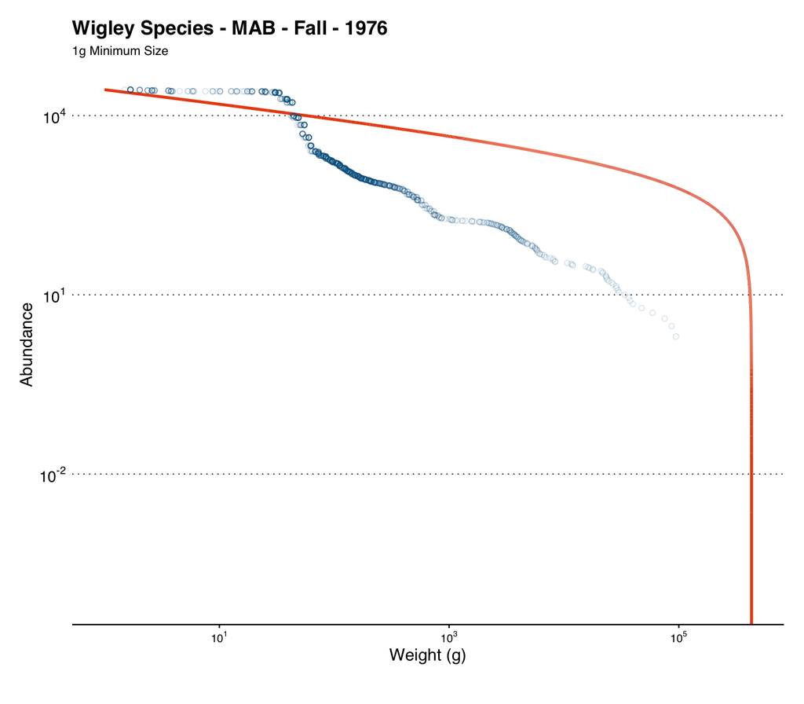

```r
# Control options
mle_results <- mle_results_1g
actual_vals <- actual_vals_1g
min_used <- mle_results_1g$xmin_fit
max_used <- mle_results_1g$xmax_fit



#### -- Plpot setup below  ---


# Power law parameters and summary details for the group of data:
b.MLE           <- mle_results$b
total_abundance <- mle_results$n
b.confMin       <- mle_results$confMin
b.confMax       <- mle_results$confMax

# Create range of x values from the group to get power law predictions
# min and max weights for power law
xmin  <- min_used
xmax  <- max_used

# Create x values (individual bodymass) to predict across
# break up the Xlim into pieces between min and max
x.PLB <- seq(
  from = xmin,
  to   = xmax,
  by = 0.1)

# get the length of that vector
x.PLB.length <- length(x.PLB)

# Y values for plot limits/bounds/predictions from bounded power law pdf
y.PLB         <- (1 - sizeSpectra::pPLB(
  x = x.PLB,
  b = b.MLE,
  xmin = min(x.PLB),
  xmax = max(x.PLB))) * total_abundance

y.PLB.confMin <- (1 - sizeSpectra::pPLB(
  x = x.PLB,
  b = b.confMin,
  xmin = min(x.PLB),
  xmax = max(x.PLB))) * total_abundance

y.PLB.confMax <- (1 - sizeSpectra::pPLB(
  x = x.PLB,
  b = b.confMax,
  xmin = min(x.PLB),
  xmax = max(x.PLB))) * total_abundance

# Put it in a df to make it easier
PLB_df <- data.frame(
  x.PLB   = x.PLB,
  y.PLB   = y.PLB,
  confMin = y.PLB.confMin,
  confMax = y.PLB.confMax) %>%
  mutate()


# 2. solve the power law function again in mutate for residuals
# need to do it twice for wmin_g and wmax_g
# Aggregate across overlapping size ranges
p_prepped <- actual_vals %>%
  isd_plot_prep(min_weight_g = min_used) %>%
  left_join(actual_vals) %>%
  select(comname, wmin_g, wmax_g, lowCount, highCount, countGTEwmin) %>%
  # Get the residuals
  mutate(
    # Estimated Abundance
    wmin_estimate = (1 - sizeSpectra::pPLB(x = wmin_g, b = b.MLE, xmin = xmin, xmax = xmax)) * total_abundance,
    wmax_estimate = (1 - sizeSpectra::pPLB(x = wmax_g, b = b.MLE, xmin = xmin, xmax = xmax)) * total_abundance,
    # Residuals
    b_resid = countGTEwmin - ((wmin_estimate + wmax_estimate)/2))



#####  Plotting Raw  ####

# Messing with the plot axes
fit_1g_gom_2000 <- ggplot() +
  geom_line(
    data = PLB_df, aes(x.PLB, y.PLB),
    color = gmri_cols("orange"),
    linewidth = 1) +
    geom_point(
      data = p_prepped %>% filter(lowCount >0),
      aes(x = (wmin_g+wmax_g)/2,
          y = countGTEwmin),
    color = gmri_cols("gmri blue"),
    alpha = 0.15,
    shape = 1) +
  scale_y_log10(
    labels = trans_format("log10", math_format(10^.x))#,
    #limits = c(10^-1, 10^6)
    ) +
  scale_x_log10(
    labels = trans_format("log10", math_format(10^.x))#,
    #limits = c(10^-1, 10^6)
    ) +
  labs(x = "Weight (g)",
       y = "Abundance",
       title = "Wigley Species - MAB - Fall - 1976",
       subtitle = "1g Minimum Size")

fit_1g_gom_2000
```

**16g Min Cutoff**

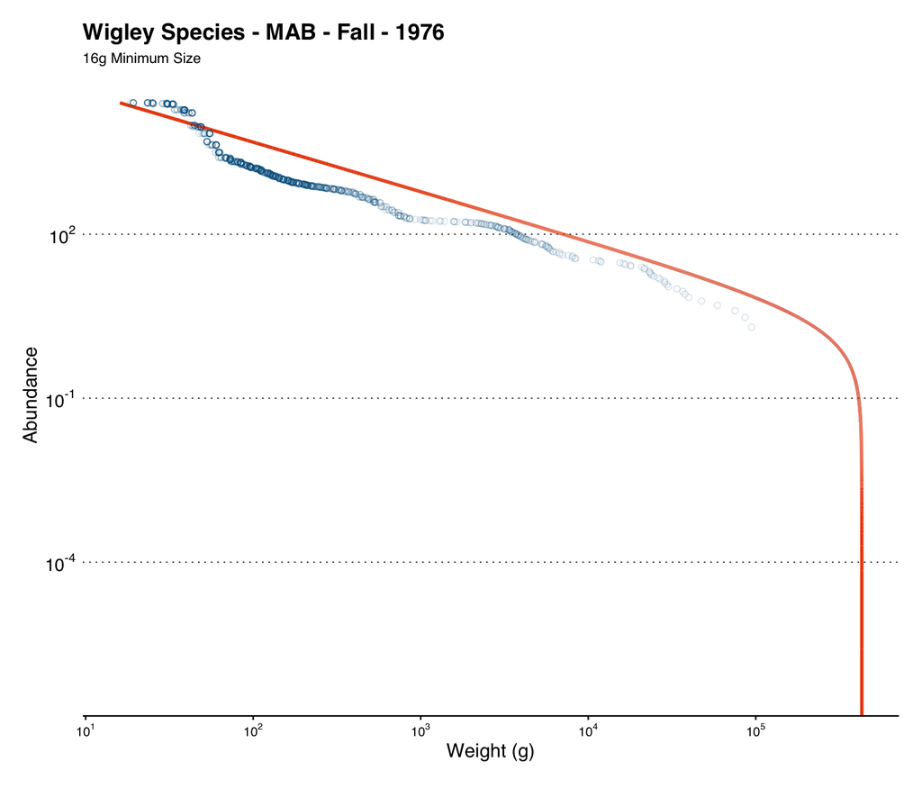

```r
# Control options
mle_results <- mle_results_16g
actual_vals <- actual_vals_16g
min_used <- mle_results_16g$xmin_fit
max_used <- mle_results_16g$xmax_fit



#### -- Plpot setup below  ---

# Power law parameters and summary details for the group of data:
b.MLE           <- mle_results$b
total_abundance <- mle_results$n
b.confMin       <- mle_results$confMin
b.confMax       <- mle_results$confMax



# Create range of x values from the group to get power law predictions
# min and max weights for power law
xmin  <- min_used
xmax  <- max_used

# Create x values (individual bodymass) to predict across
# break up the Xlim into pieces between min and max
x.PLB <- seq(
  from = xmin,
  to   = xmax,
  by = 0.1)

# get the length of that vector
x.PLB.length <- length(x.PLB)

# Y values for plot limits/bounds/predictions from bounded power law pdf
y.PLB         <- (1 - sizeSpectra::pPLB(x = x.PLB, b = b.MLE, xmin = min(x.PLB), xmax = max(x.PLB))) * total_abundance
y.PLB.confMin <- (1 - sizeSpectra::pPLB(x = x.PLB, b = b.confMin, xmin = min(x.PLB), xmax = max(x.PLB))) * total_abundance
y.PLB.confMax <- (1 - sizeSpectra::pPLB(x = x.PLB, b = b.confMax, xmin = min(x.PLB), xmax = max(x.PLB))) * total_abundance

# Put it in a df to make it easier
PLB_df <- data.frame(
  x.PLB   = x.PLB,
  y.PLB   = y.PLB,
  confMin = y.PLB.confMin,
  confMax = y.PLB.confMax) %>%
  mutate()


# 2. solve the power law function again in mutate for residuals
# need to do it twice for wmin_g and wmax_g
# Aggregate across overlapping size ranges
p_prepped <- actual_vals %>%
  isd_plot_prep(min_weight_g = min_used) %>%
  left_join(actual_vals) %>%
  select(comname, wmin_g, wmax_g, lowCount, highCount, countGTEwmin) %>%
  # Get the residuals
  mutate(
    # Estimated Abundance
    wmin_estimate = (1 - sizeSpectra::pPLB(x = wmin_g, b = b.MLE, xmin = xmin, xmax = xmax)) * total_abundance,
    wmax_estimate = (1 - sizeSpectra::pPLB(x = wmax_g, b = b.MLE, xmin = xmin, xmax = xmax)) * total_abundance,
    # Residuals
    b_resid = countGTEwmin - ((wmin_estimate + wmax_estimate)/2))



#####  Plotting Raw  ####

# Messing with the plot axes
fit_16g_gom_2000 <- ggplot() +
  geom_line(
    data = PLB_df, aes(x.PLB, y.PLB),
    color = gmri_cols("orange"),
    linewidth = 1) +
    geom_point(
      data = p_prepped %>% filter(lowCount >0),
      aes(x = (wmin_g+wmax_g)/2,
          y = countGTEwmin),
    color = gmri_cols("gmri blue"),
    alpha = 0.15,
    shape = 1) +
  scale_y_log10(
    labels = trans_format("log10", math_format(10^.x))#,
    #limits = c(10^-1, 10^6)
    ) +
  scale_x_log10(
    labels = trans_format("log10", math_format(10^.x))#,
    #limits = c(10^-1, 10^6)
    ) +
  labs(x = "Weight (g)",
       y = "Abundance",
       title = "Wigley Species - MAB - Fall - 1976",
       subtitle = "16g Minimum Size")

fit_16g_gom_2000
```

**16g up-to 50kg**

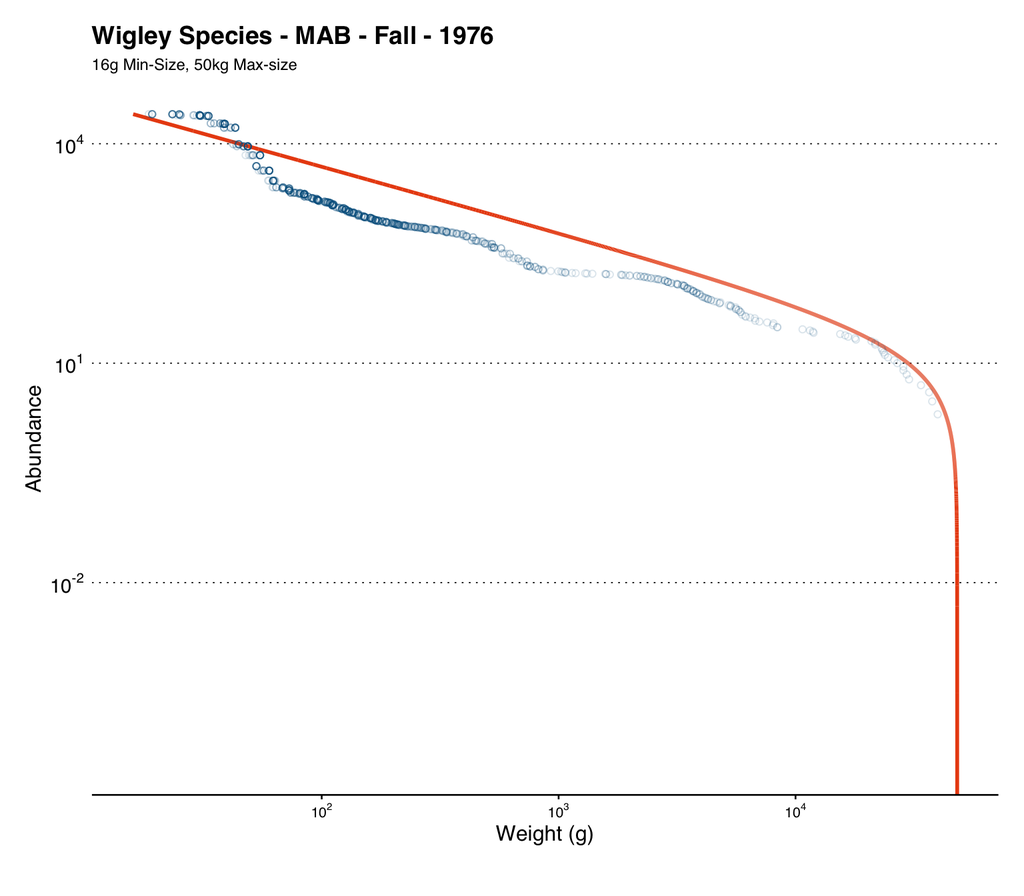

```r
# Control options
mle_results <- mle_results_16to50kg
actual_vals <- actual_vals_16to50kg
min_used <- mle_results_16to50kg$xmin_fit
max_used <- mle_results_16to50kg$xmax_fit


#### -- Plpot setup below  ---

# Power law parameters and summary details for the group of data:
b.MLE           <- mle_results$b
total_abundance <- mle_results$n
b.confMin       <- mle_results$confMin
b.confMax       <- mle_results$confMax


# Create range of x values from the group to get power law predictions
# min and max weights for power law
xmin  <- min_used
xmax  <- max_used

# Create x values (individual bodymass) to predict across
# break up the Xlim into pieces between min and max
x.PLB <- seq(
  from = xmin,
  to   = xmax,
  by = 0.1)

# get the length of that vector
x.PLB.length <- length(x.PLB)

# Y values for plot limits/bounds/predictions from bounded power law pdf
y.PLB         <- (1 - sizeSpectra::pPLB(x = x.PLB, b = b.MLE, xmin = min(x.PLB), xmax = max(x.PLB))) * total_abundance
y.PLB.confMin <- (1 - sizeSpectra::pPLB(x = x.PLB, b = b.confMin, xmin = min(x.PLB), xmax = max(x.PLB))) * total_abundance
y.PLB.confMax <- (1 - sizeSpectra::pPLB(x = x.PLB, b = b.confMax, xmin = min(x.PLB), xmax = max(x.PLB))) * total_abundance

# Put it in a df to make it easier
PLB_df <- data.frame(
  x.PLB   = x.PLB,
  y.PLB   = y.PLB,
  confMin = y.PLB.confMin,
  confMax = y.PLB.confMax) %>%
  mutate()


# 2. solve the power law function again in mutate for residuals
# need to do it twice for wmin_g and wmax_g
# Aggregate across overlapping size ranges
p_prepped <- actual_vals %>%
  isd_plot_prep(min_weight_g = min_used) %>%
  left_join(actual_vals) %>%
  select(comname, wmin_g, wmax_g, lowCount, highCount, countGTEwmin) %>%
  # Get the residuals
  mutate(
    # Estimated Abundance
    wmin_estimate = (1 - sizeSpectra::pPLB(x = wmin_g, b = b.MLE, xmin = xmin, xmax = xmax)) * total_abundance,
    wmax_estimate = (1 - sizeSpectra::pPLB(x = wmax_g, b = b.MLE, xmin = xmin, xmax = xmax)) * total_abundance,
    # Residuals
    b_resid = countGTEwmin - ((wmin_estimate + wmax_estimate)/2))



#####  Plotting Raw  ####

# Messing with the plot axes
fit_16to50kg_gom_2000 <- ggplot() +
  geom_line(
    data = PLB_df, aes(x.PLB, y.PLB),
    color = gmri_cols("orange"),
    linewidth = 1) +
    geom_point(
      data = p_prepped %>% filter(lowCount >0),
      aes(x = (wmin_g+wmax_g)/2,
          y = countGTEwmin),
    color = gmri_cols("gmri blue"),
    alpha = 0.15,
    shape = 1) +
  scale_y_log10(
    labels = trans_format("log10", math_format(10^.x))#,
    #limits = c(10^-1, 10^6)
    ) +
  scale_x_log10(
    labels = trans_format("log10", math_format(10^.x))#,
    #limits = c(10^-1, 10^6)
    ) +
  labs(x = "Weight (g)",
       y = "Abundance",
       title = "Wigley Species - MAB - Fall - 1976",
       subtitle = "16g Min-Size, 50kg Max-size")



fit_16to50kg_gom_2000
```

For the above plot I’ve filtered the input data to below 50kg, and then allowed the largest size present set the parameter `xmax`.